# Time series

Vitor Borges Jr

19/07/2018

## Basics - Time Series Modeling

There are few premisses we need to check before proceed with time series analyses.

## Stationary Series

To be calssified as stationary a series must meet three basic criterion: 1. The mean of the series should not be a function of time rather should be a constant. 2. The variance of the series should not be a function of time (homocedasticity). 3. The covariance of the i th term and the (i + m) th term should not be a function of time.

## Why do I care about ‘stationarity’ of a time series?

## 2 Explotration of time series data in R

Loading the data set

```r
data("AirPassengers")
```

The data serires must be in a time series format

```r
class(AirPassengers)
```

```
## [1] "ts"
```

The strat of the time series

```r
start(AirPassengers)
```

```
## [1] 1949    1
```

The end of the time series

```r
end(AirPassengers)
```

```
## [1] 1960   12
```

The cycle of this time series is 12 months in a year

```r
frequency(AirPassengers)
```

```
## [1] 12
```

```r
summary(AirPassengers)
```

```
##    Min. 1st Qu.  Median    Mean 3rd Qu.    Max.
##   104.0   180.0   265.5   280.3   360.5   622.0
```

# Detailed metrics

plot of the time series - the number of passengers are distributed across the spectrum

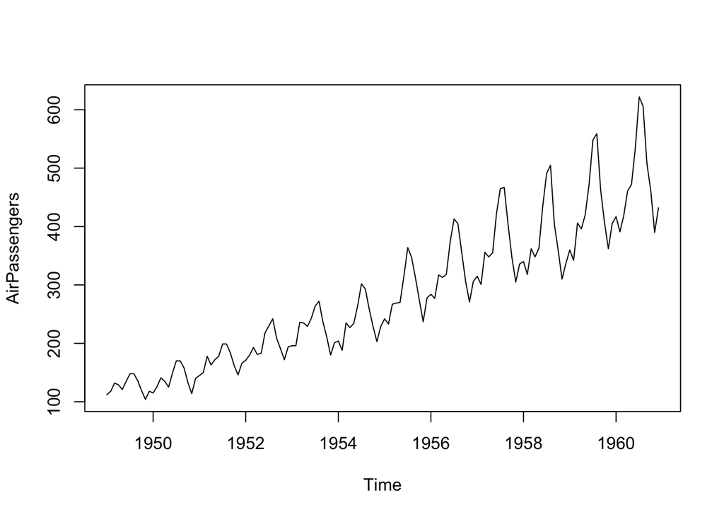

```r
plot(AirPassengers)
```

Fit in a line

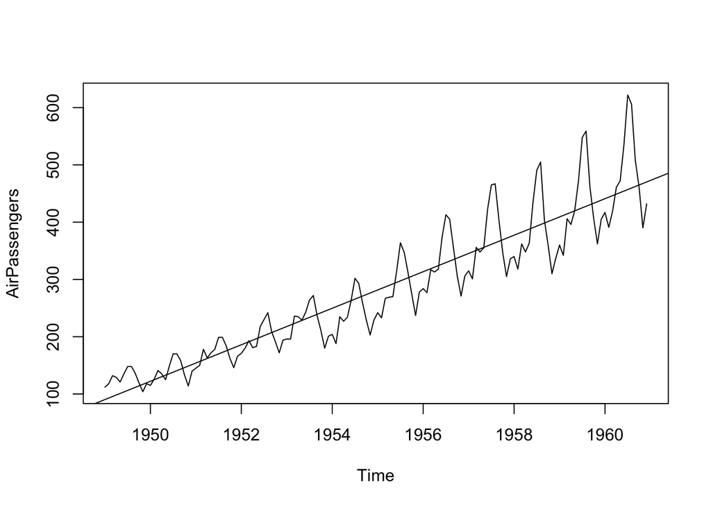

```r
plot(AirPassengers)
abline(lm(AirPassengers ~ time(AirPassengers)))
```

Print the cycle across years

```r
cycle(AirPassengers)
```

```
##      Jan Feb Mar Apr May Jun Jul Aug Sep Oct Nov Dec
## 1949   1   2   3   4   5   6   7   8   9  10  11  12
## 1950   1   2   3   4   5   6   7   8   9  10  11  12
## 1951   1   2   3   4   5   6   7   8   9  10  11  12
## 1952   1   2   3   4   5   6   7   8   9  10  11  12
## 1953   1   2   3   4   5   6   7   8   9  10  11  12
## 1954   1   2   3   4   5   6   7   8   9  10  11  12
## 1955   1   2   3   4   5   6   7   8   9  10  11  12
## 1956   1   2   3   4   5   6   7   8   9  10  11  12
## 1957   1   2   3   4   5   6   7   8   9  10  11  12
## 1958   1   2   3   4   5   6   7   8   9  10  11  12
## 1959   1   2   3   4   5   6   7   8   9  10  11  12
## 1960   1   2   3   4   5   6   7   8   9  10  11  12
```

Aggregate the cylces and display a year on year trend

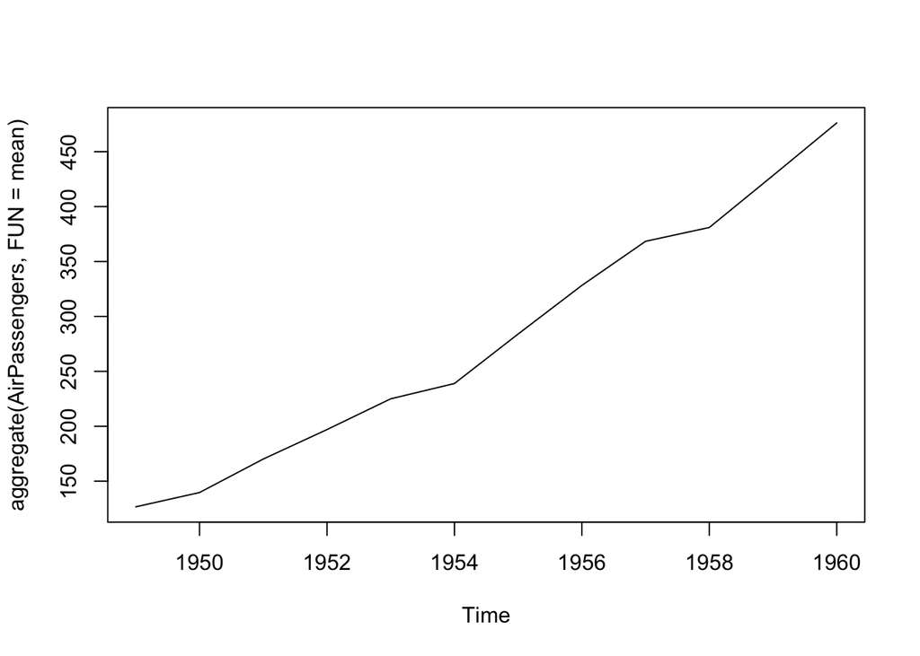

```r
plot(aggregate(AirPassengers, FUN = mean))
```

Box plot across months will give us a sense on seasona effect

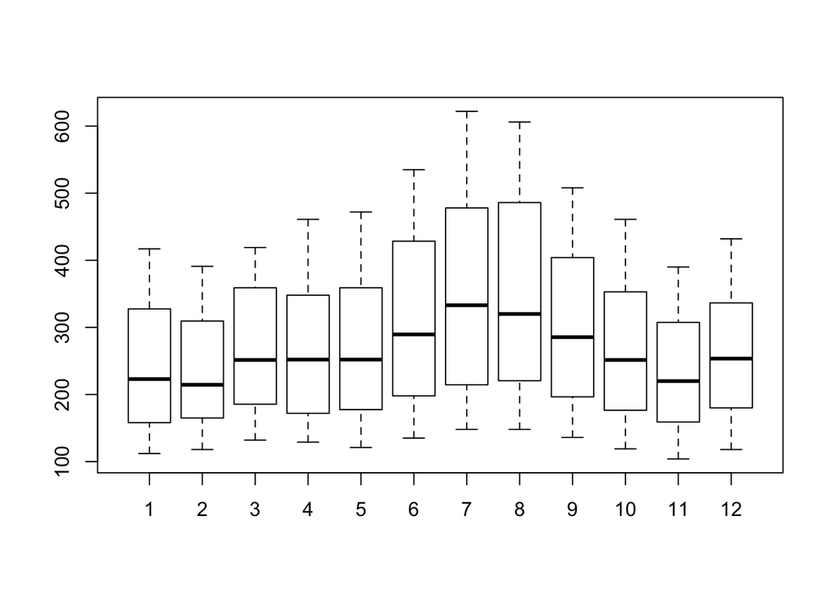

```r
boxplot(AirPassengers ~ cycle(AirPassengers))
```

## Important inferences

1. The year on year trend cleaerly shiws that the passengers have been increrasing without fail
2. The variance and the mean value in July and August is much higher than rest of the months
3. Even though the mean value of each month is quite different their variance is small. Hence, we have strong seasonal effects with a cycle of 12 months or less.

## Introduction to ARMA time series modeling